# Gapminder Revisited: Explore Two Variables

Ursula Neumann

February 15, 2018

## Introduction

On the Gapminder website I found two datasets, one for female BMI over time (“Body Mass Index (BMI), women, Kg/m2”) and the other for total cholesterol levels over time (“Cholesterol (fat) in blood, women, mmol/L”). I thought it would be interesting to see how these parameters change over time and whether the BMI and cholesterol are positively correlated as I would expect. Both datasets are provided by the MRC-HPA Center for Environment and Health and span the years 1980 - 2008 for 199 countries.

## Load datasets and prepare the dataframe for analysis

Below I have loaded both of the datasets, transformed them into “tall” datasets using the gather function, then joined the 2 datasets together on country and year to produce a dataframe with the columns: country, year, BMI and cholesterol.

```r
# Load the necessary libraries
library("tidyr")
library("dplyr")
```

```r
library("ggplot2")
library("gridExtra")
# Load the BMI dataset
df1 <- read.csv('female_BMI.csv', check.names = FALSE)
head(df1)
```

```
##               Country     1980     1981     1982     1983     1984
## 1         Afghanistan 20.44348 20.47765 20.52292 20.56493 20.60867
## 2             Albania 25.17427 25.19088 25.20032 25.21906 25.22359
## 3             Algeria 23.67764 23.80702 23.92626 24.03604 24.13630
## 4             Andorra 25.67324 25.69018 25.69922 25.70089 25.70584
## 5              Angola 20.06763 20.12766 20.19464 20.26439 20.34110
## 6 Antigua and Barbuda 24.22235 24.34043 24.43933 24.55735 24.70423
##       1985     1986     1987     1988     1989     1990     1991     1992
## 1 20.64796 20.68983 20.70902 20.71512 20.71421 20.70504 20.70117 20.67746
## 2 25.21257 25.20939 25.18918 25.16965 25.15370 25.13877 25.04670 24.96615
## 3 24.24213 24.33652 24.42523 24.50904 24.59436 24.67546 24.75504 24.84210
## 4 25.70877 25.71239 25.72437 25.74523 25.77649 25.81199 25.85168 25.87593
## 5 20.42624 20.51389 20.60929 20.70945 20.80873 20.91400 21.00432 21.08987
## 6 24.86193 25.02937 25.18394 25.35149 25.52673 25.67301 25.81131 25.95531
##       1993     1994     1995     1996     1997     1998     1999     2000
## 1 20.63639 20.59074 20.56750 20.55575 20.56759 20.59306 20.61717 20.61850
## 2 24.93558 24.93562 24.93706 24.96643 24.96754 25.00220 25.06254 25.12797
## 3 24.92523 24.99550 25.07258 25.15000 25.22635 25.30970 25.40139 25.49389
## 4 25.89671 25.91898 25.93933 25.96645 25.99661 26.03351 26.07432 26.10622
## 5 21.13495 21.18443 21.25985 21.36478 21.47863 21.60939 21.76054 21.91293
## 6 26.06340 26.15508 26.22408 26.29350 26.37160 26.44720 26.52800 26.61231
##       2001     2002     2003     2004     2005     2006     2007     2008
## 1 20.61353 20.65274 20.70828 20.76927 20.83858 20.91021 20.99060 21.07402
## 2 25.20332 25.27082 25.33198 25.39804 25.46525 25.53328 25.59394 25.65726
## 3 25.59477 25.69948 25.81168 25.93081 26.03886 26.15054 26.26096 26.36841
## 4 26.14707 26.19542 26.23892 26.28851 26.32247 26.36846 26.40095 26.43196
## 5 22.07646 22.26093 22.44571 22.63536 22.83412 23.04406 23.26330 23.48431
## 6 26.68539 26.76278 26.84799 26.96384 27.09834 27.23278 27.37364 27.50545
```

```r
# Gather the data into columns of country, year, and BMI
df_BMI <- gather(df1, key = "year", value = "BMI", 2:dim(df1)[2])
head(df_BMI)
```

```
##               Country year      BMI
## 1         Afghanistan 1980 20.44348
## 2             Albania 1980 25.17427
## 3             Algeria 1980 23.67764
## 4             Andorra 1980 25.67324
## 5              Angola 1980 20.06763
## 6 Antigua and Barbuda 1980 24.22235
```

```r
# Load the cholesterol dataset
df2 <- read.csv('female_cholesterol.csv', check.names = FALSE)
head(df2)
```

```
##   TC female (mmol/L), age standardized mean     1980     1981     1982
## 1                               Afghanistan 4.644476 4.637118 4.630770
## 2                                   Albania 5.039529 5.036610 5.033352
## 3                                   Algeria 4.976215 4.975257 4.974508
## 4                                   Andorra 6.132187 6.101291 6.069412
## 5                                    Angola 4.789354 4.769557 4.751330
## 6                       Antigua and Barbuda 5.013913 5.006714 5.000293
##       1983     1984     1985     1986     1987     1988     1989     1990
## 1 4.625318 4.619873 4.613289 4.607698 4.598080 4.583443 4.567768 4.548429
## 2 5.028138 5.022292 5.018456 5.012306 5.008334 5.002822 4.998255 4.991347
## 3 4.976556 4.976963 4.977419 4.974378 4.971097 4.963965 4.957217 4.951503
## 4 6.038793 6.008447 5.977998 5.948506 5.918512 5.890226 5.864313 5.836336
## 5 4.733550 4.719231 4.707431 4.693793 4.683528 4.674458 4.665655 4.654712
## 6 4.997209 4.996626 4.998084 5.001350 5.003486 5.008585 5.011400 5.014208
##       1991     1992     1993     1994     1995     1996     1997     1998
```

[output cut: 20 more lines]

```r
# Gather the data into columns of country, year, and cholesterol
df_chol <- gather(df2, key = "year", value = "cholesterol", 2:dim(df2)[2])
colnames(df_chol)[1] <- "Country"
head(df_chol)
```

```
##               Country year cholesterol
## 1         Afghanistan 1980    4.644476
## 2             Albania 1980    5.039529
## 3             Algeria 1980    4.976215
## 4             Andorra 1980    6.132187
## 5              Angola 1980    4.789354
## 6 Antigua and Barbuda 1980    5.013913
```

```r
# Join the two datasets using an inner join on country and year
df <- inner_join(df_BMI, df_chol, by = c("Country", "year"))
head(df)
```

```
##               Country year      BMI cholesterol
## 1         Afghanistan 1980 20.44348    4.644476
## 2             Albania 1980 25.17427    5.039529
## 3             Algeria 1980 23.67764    4.976215
## 4             Andorra 1980 25.67324    6.132187
## 5              Angola 1980 20.06763    4.789354
## 6 Antigua and Barbuda 1980 24.22235    5.013913
```

```r
# Change the year variable to a numeric class
df$year <- as.numeric(df$year)
```

```r
# View summaries of BMI and cholesterol
summary(df$BMI)
```

```
##    Min. 1st Qu.  Median    Mean 3rd Qu.    Max.
##   18.47   22.70   25.00   24.67   26.28   35.02
```

```r
summary(df$cholesterol)
```

```
##    Min. 1st Qu.  Median    Mean 3rd Qu.    Max.
##   3.974   4.575   4.877   4.912   5.215   6.200
```

# Plotting BMI and cholesterol over time

First I wanted to observe how BMI and cholesterol change over the full time span available. There is a very obvious, steady, and step-wise increse in BMI and decrease in cholesterol over time. Given modern day’s more sedentary lifestyle with easy access to poor food choices I am not surprised to observe an incremental increase in BMI over time. However, while I expected cholesterol levels either to remain steady or to increase as well, the opposite is observed.

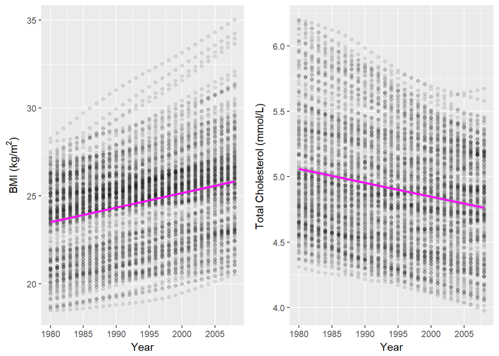

```r
# Plot BMI and cholesterol over time
p1 <- ggplot(aes(x = year,
           y = BMI),
       data = df) +
  geom_point(alpha = 1/10) +
  scale_x_continuous(breaks = seq(1980, 2010, 5)) +
  geom_smooth(method = 'lm', color = 'magenta') +
  labs(x = expression(paste("Year")),
       y = expression(paste("BMI (kg/m"^2, ")")))

p2 <- ggplot(aes(x = year,
           y = cholesterol),
       data = df) +
  geom_point(alpha = 1/10) +
  scale_x_continuous(breaks = seq(1980, 2010, 5)) +
  geom_smooth(method = 'lm', color = 'magenta') +
  labs(x = expression(paste("Year")),
       y = expression(paste("Total Cholesterol (mmol/L)")))

grid.arrange(p1, p2, nrow=1)
```

## Scatterplots of cholesterol vs BMI over the full time available

First I wanted to plot a scatterplot of cholesterol vs BMI over the complete dataset just to see what it would look like. The results were not what I expected as the graph looked like various “snakes”, or a clear trail of points in a row. Each snake is a country and for most of the countries the 1980 point is at the top left of the row, and as the years go by, the points descend downward and to the right. This is summarizied in the next figure below where the dataset is grouped by year and the means of both cholesterol and BMI are plotted. I thought these were very strange looking scatterplots, perhaps because of the incremental changes over time. Therefore I also grouped the data by country which produced a more typical looking scatterplot showing a positive correlation between cholesterol and BMI.

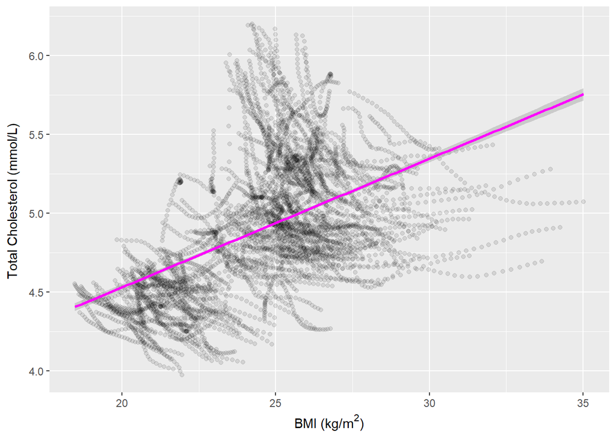

```r
# For the complete dataset, graph a scatterplot of cholesterol vs BMI
ggplot(aes(x = BMI,
           y = cholesterol),
       data = df) +
  geom_point(alpha = 1/10) +
  geom_smooth(method = 'lm', color = 'magenta') +
  labs(x = expression(paste("BMI (kg/m"^2, ")")),
       y = expression(paste("Total Cholesterol (mmol/L)")))
```

```r
# Group the dataset by year and calculate the mean BMI and cholesterol
year_groups <- group_by(df, year)
df_by_year <- summarize(year_groups,
          mean_BMI = mean(BMI),
          mean_chol = mean(cholesterol),
          n = n())
df_by_year <- arrange(df_by_year, year)
head(df_by_year)
```

```
## # A tibble: 6 x 4
##    year mean_BMI mean_chol     n
##   <dbl>    <dbl>     <dbl> <int>
## 1  1980     23.6      5.08   199
## 2  1981     23.6      5.07   199
## 3  1982     23.7      5.05   199
## 4  1983     23.8      5.04   199
## 5  1984     23.9      5.03   199
## 6  1985     23.9      5.01   199
```

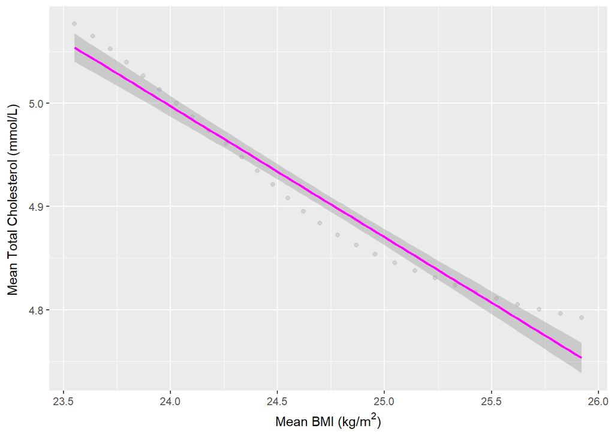

```r
# Graph a scatterplot of mean cholesterol vs mean BMI on the data grouped by year
ggplot(aes(x = mean_BMI,
           y = mean_chol),
       data = df_by_year) +
  geom_point(alpha = 1/10) +
  geom_smooth(method = 'lm', color = 'magenta') +
  labs(x = expression(paste("Mean BMI (kg/m"^2, ")")),
       y = expression(paste("Mean Total Cholesterol (mmol/L)")))
```

```r
# Group the dataset by country and calculate the mean BMI and cholesterol
country_groups <- group_by(df, Country)
df_by_country <- summarize(country_groups,
          mean_BMI = mean(BMI),
          mean_chol = mean(cholesterol),
          n = n())
df_by_country <- arrange(df_by_country, Country)
head(df_by_country)
```

```
## # A tibble: 6 x 4
##   Country             mean_BMI mean_chol     n
##   <fct>                  <dbl>     <dbl> <int>
## 1 Afghanistan             20.7      4.45    29
## 2 Albania                 25.2      4.96    29
## 3 Algeria                 25.0      4.91    29
## 4 Andorra                 26.0      5.74    29
## 5 Angola                  21.4      4.60    29
## 6 Antigua and Barbuda     26.0      4.98    29
```

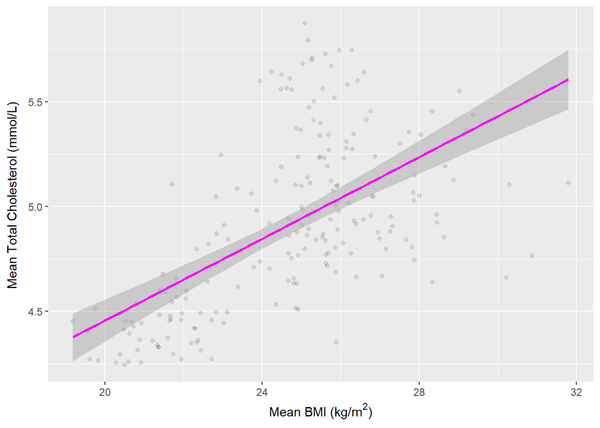

```r
# Graph a scatterplot of mean cholesterol vs mean BMI on the data grouped by year
ggplot(aes(x = mean_BMI,
           y = mean_chol),
       data = df_by_country) +
  geom_point(alpha = 1/10) +
  geom_smooth(method = 'lm', color = 'magenta') +
  labs(x = expression(paste("Mean BMI (kg/m"^2, ")")),
       y = expression(paste("Mean Total Cholesterol (mmol/L)")))
```

## Scatterplots and correlation coefficients of cholesterol vs BMI at specific timepoints

Because both cholesterol and BMI are changing over time I also decided to investigate the correlation between these variables at 2 different timepoints at the beginning and end of the timeframe, 1980 and 2008 respectively. Similar to the graph above both of these graphs show a moderately strong positive correlation between cholesterol and BMI (0.64 for 1980 and 51 for 2008). The graphs were purposely plotted with the same scale for both the x- and y-axis. Although this leads to more blank space on the plot, you can observe that BMI is increasing over time while cholesterol is decreasing.

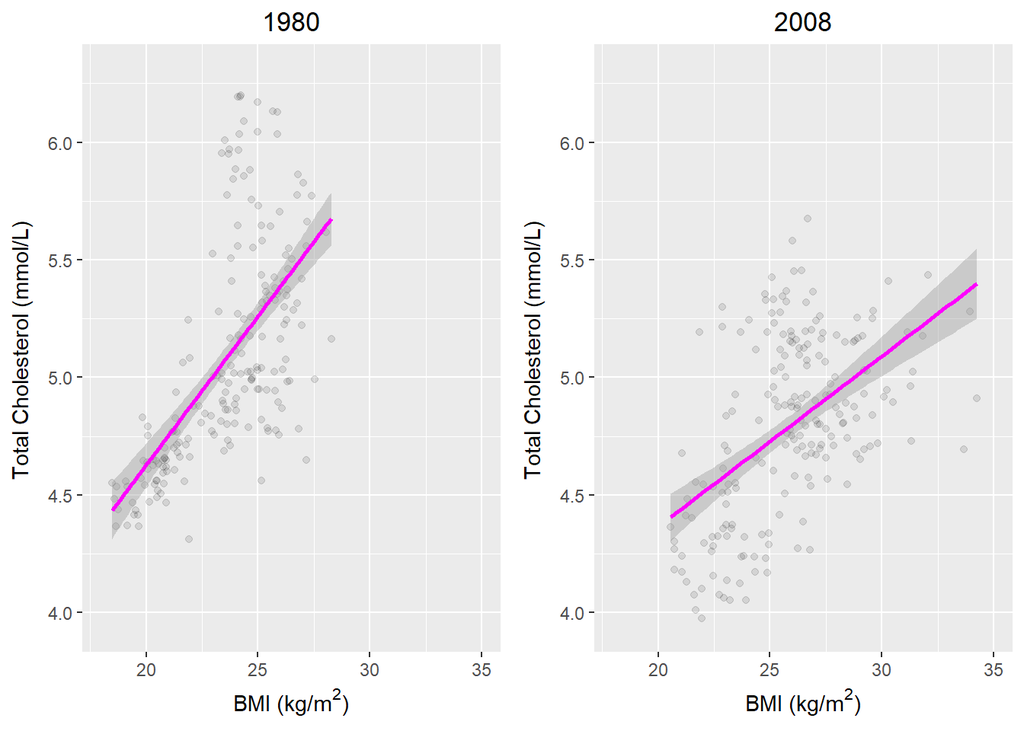

```r
# Graph a scatterplot of cholesterol vs BMI for 1980 and 2008 for all countries
p3 <- ggplot(aes(x = BMI,
           y = cholesterol),
       data = subset(df, df$year == 1980)) +
  geom_point(alpha = 1/10) +
  geom_smooth(method = 'lm', color = 'magenta') +
  xlim(18, 35) +
  ylim(3.95, 6.3) +
  ggtitle("1980") +
  theme(plot.title = element_text(hjust = 0.5)) +
  labs(x = expression(paste("BMI (kg/m"^2, ")")),
       y = expression(paste("Total Cholesterol (mmol/L)")))

p4 <- ggplot(aes(x = BMI,
           y = cholesterol),
       data = subset(df, df$year == 2008)) +
  geom_point(alpha = 1/10) +
  geom_smooth(method = 'lm', color = 'magenta') +
  xlim(18, 35) +
  ylim(3.95, 6.3) +
  ggtitle("2008") +
  theme(plot.title = element_text(hjust = 0.5)) +
  labs(x = expression(paste("BMI (kg/m"^2, ")")),
       y = expression(paste("Total Cholesterol (mmol/L)")))

grid.arrange(p3, p4, nrow=1)
```

```r
# Calculate Pearson's correlation for 1980 and 2008 data
cor.test(~ cholesterol + BMI, df, year == 1980)
```

```
##
##  Pearson's product-moment correlation
##
## data:  cholesterol and BMI
## t = 11.621, df = 197, p-value < 2.2e-16
## alternative hypothesis: true correlation is not equal to 0
## 95 percent confidence interval:
##  0.5471897 0.7135386
## sample estimates:
##      cor
## 0.637742
```

```r
cor.test(~ cholesterol + BMI, df, year == 2008)
```

```
##
##  Pearson's product-moment correlation
##
## data:  cholesterol and BMI
## t = 8.4128, df = 197, p-value = 8.066e-15
## alternative hypothesis: true correlation is not equal to 0
## 95 percent confidence interval:
##  0.4039035 0.6096094
## sample estimates:
##       cor
## 0.5141112
```

## Resources

1. https://rpubs.com/anthonycerna/popdensityandoilconsumption
2. https://rstudio-pubs-static.s3.amazonaws.com/136237_170402e5f0b54561bf7605bdea98267a.html
3. https://stackoverflow.com/questions/6081439/changing-column-names-of-a-data-frame
4. https://stackoverflow.com/questions/40675778/center-plot-title-in-ggplot2
5. http://grokbase.com/t/r/r-help/083kkxza9c/r-using-subset-in-correlation-analysis